# Practical Machine Learning Course Project

Dec 2017

## Introduction

The data for this project came from this source: http://groupware.les.inf.puc-rio.br/har

## Weight Lifting Exercise Dataset

The approach we propose for the Weight Lifting Exercises dataset is to investigate “how (well)” an activity was performed by the wearer.

Six young health participants were asked to perform one set of 10 repetitions of the Unilateral Dumbbell Biceps Curl in five different fashions: exactly according to the specification (Class A), throwing the elbows to the front (Class B), lifting the dumbbell only halfway (Class C), lowering the dumbbell only halfway (Class D) and throwing the hips to the front (Class E).

Class A corresponds to the specified execution of the exercise, while the other 4 classes correspond to common mistakes.

## Read the data

```r
raw.training <- fread("pml-training.csv", na.strings = c("NA","",'#DIV/0!'))
raw.testing <- fread("pml-testing.csv", na.strings = c("NA","",'#DIV/0!'))
dim(raw.testing); dim(raw.training)
```

```
## [1]  20 160
```

```
## [1] 19622   160
```

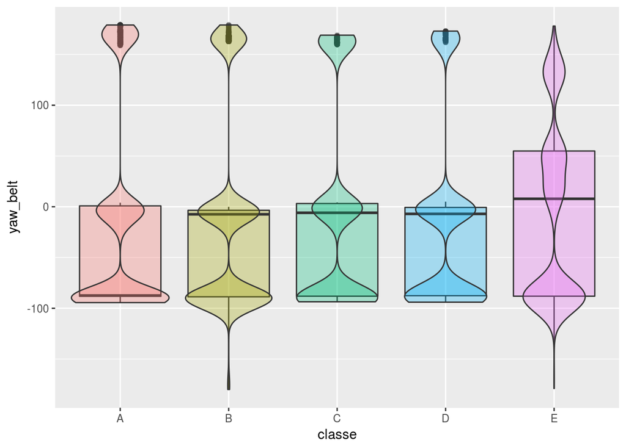

```r
p <- ggplot(raw.training, aes(classe, yaw_belt))+geom_boxplot(aes(fill=classe), alpha=0.3)+geom_violin(aes(fill=classe), alpha=0.3)+theme(legend.position = "NA")
p
```

This plot demonstrates that the data have complex structure and probabilistic approaches would fail without proper data transformations.

## Exploratory Data Analysis

### Remove almost absent variables

Some variables have more than 19200 observations that are “NA”. Get rid of them:

```r
missing.columns <- names(raw.training)[colSums(is.na(raw.training)) != 0]
raw.training[, (missing.columns):=NULL]
missing.columns <- names(raw.testing)[colSums(is.na(raw.testing)) != 0]
raw.testing[, (missing.columns):=NULL]

dim(raw.training); dim(raw.testing)
```

```
## [1] 19622    60
```

```
## [1] 20 60
```

## Preprocessing

### Standardizing and dealing with low variance variables

It is a good practice to standardize data, to find the predictors with near-zero variance and exclude them from analysis. Here I use *preProcess()* and *nearZeroVar()* functions from *caret* package.

```r
train.noClasse <- raw.training %>% select(-classe)
charIdx <- which(lapply(train.noClasse, class) %in% "character")
preVar <- preProcess(train.noClasse[,-c(charIdx), with=F], method=c('knnImpute', 'center', 'scale'))
train.transVar <- predict(preVar, train.noClasse[,-c(charIdx), with=F])
nz <- nearZeroVar(train.transVar, allowParallel = T)
names(train.noClasse)[nz] # NULL
```

```
## character(0)
```

### Multicollinearity

Exclude collinear variables with *findCorrelation()* function, as well as other unnecessary variables (“raw_timestamp_part_1”, “raw_timestamp_part_2”, “num_window”). Despite the fact that some algorithms (such as random forests) are insensitive to collinear predictors, excluding such variables can speed up the computations without affecting accuracy.

```r
# remove character variables
cor.train <- cor(train.transVar, method="pearson")
highCor <- findCorrelation(cor.train, cutoff=0.75)
names(train.transVar)[highCor]
```

```
##  [1] "accel_belt_z"      "roll_belt"         "accel_belt_y"
##  [4] "accel_arm_y"       "total_accel_belt"  "accel_dumbbell_z"
##  [7] "accel_belt_x"      "magnet_belt_x"     "magnet_dumbbell_x"
## [10] "accel_dumbbell_y"  "magnet_dumbbell_y" "magnet_dumbbell_z"
## [13] "accel_arm_x"       "accel_dumbbell_x"  "accel_arm_z"
## [16] "magnet_arm_y"      "magnet_belt_z"     "accel_forearm_y"
## [19] "gyros_dumbbell_x"  "gyros_forearm_y"   "gyros_dumbbell_z"
## [22] "gyros_arm_x"
```

```r
# exclude these variables
train.transVar[, (highCor):=NULL]

# remove other unnecessary variables
unVar <- c("raw_timestamp_part_1", "raw_timestamp_part_2", "num_window")
train.transVar[, (unVar):=NULL]
dim(train.transVar)
```

```
## [1] 19622    30
```

```r
train.transVar$classe <- as.factor(raw.training$classe)
```

Now we have only 30 predictors in the dataset.

## Train the model

### Creating data sets

```r
set.seed(1234)
inTrain <- createDataPartition(train.transVar$classe, p=3/4, list=F)
training <- train.transVar[inTrain,]
validation <- train.transVar[-inTrain,]
dim(training); dim(validation)
```

```
## [1] 14718    31
```

```
## [1] 4904   31
```

### Cross-validation and optimization of the model’s parameters

I use random forest algorithm (as one of the most accurate algorithms) with 10 fold cross validation.

```r
fitRF <- train(classe ~., method="rf", data=training, trControl=trainControl(method='cv', number=10), allowParallel=TRUE, importance=TRUE )
```

### Variable importance

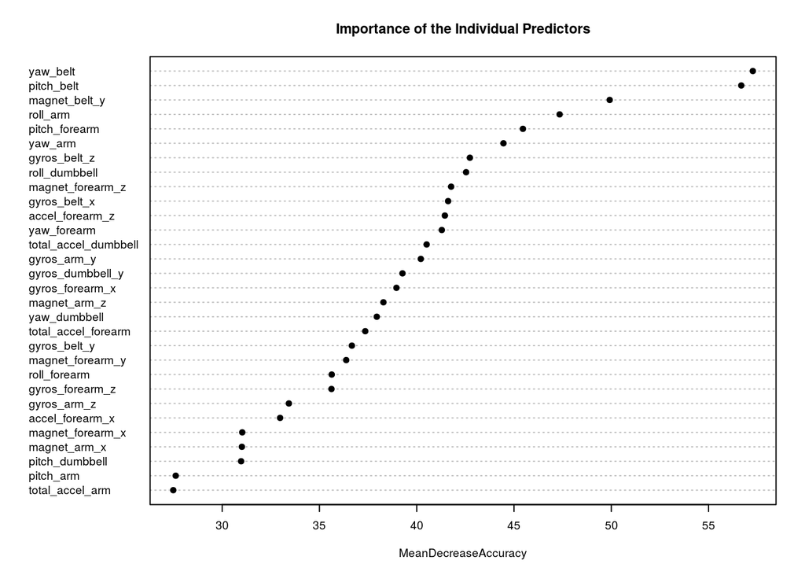

```r
varImpPlot(fitRF$finalModel, sort = TRUE, type = 1, pch = 19, col = 1, cex = 0.6, main = "Importance of the Individual Predictors")
```

```r
confusionMatrix(fitRF)
```

```
## Cross-Validated (10 fold) Confusion Matrix
##
## (entries are percentual average cell counts across resamples)
##
##           Reference
## Prediction    A    B    C    D    E
##          A 28.4  0.1  0.0  0.0  0.0
##          B  0.0 19.2  0.1  0.0  0.0
##          C  0.0  0.0 17.2  0.2  0.0
##          D  0.0  0.0  0.1 16.1  0.0
##          E  0.0  0.0  0.0  0.0 18.3
##
##  Accuracy (average) : 0.9921
```

### Prediction on Validation set

```r
predValid <- predict(fitRF, validation)
confMat <- confusionMatrix(validation$classe, predValid)
confMat$table
```

```
##           Reference
## Prediction    A    B    C    D    E
##          A 1395    0    0    0    0
##          B    6  941    2    0    0
##          C    0   12  840    3    0
##          D    0    0    9  794    1
##          E    0    0    0    0  901
```

### Accuracy on validation data set

```r
acc <- postResample(validation$classe, predValid)
modAcc <- acc[[1]]
modAcc
```

```
## [1] 0.9932708
```

### Out of sample error

```r
OoSErr <- 1 - modAcc
OoSErr
```

```
## [1] 0.006729201
```

## Applying the model to 20 test cases

Now I apply my model to test data set to submit the results to Course Project Prediction Quiz. But first I need to preprocess test data set in the same manner as the training data set.

```r
charIdx <- which(lapply(raw.testing, class) %in% "character")
preVar <- preProcess(raw.testing[,-c(charIdx), with=F], method=c('knnImpute', 'center', 'scale'))
test.transVar <- predict(preVar, raw.testing[,-c(charIdx), with=F])
unVar <- c("raw_timestamp_part_1", "raw_timestamp_part_2", "num_window", "problem_id")
test.transVar[, (unVar):=NULL]
```

And then make a prediction

```r
test.prediction <- predict(fitRF, test.transVar)
test.prediction
```

```
##  [1] E A A A A E D B A A B A D A E E E B B B
## Levels: A B C D E
```